# Recall performance for objects inside the rooms

# 1 Visual inspection of the data

# 2 Novelty Benefits

## 2.1 Check the data

- **Is there any corrected hit rate < 0?**
- There are 0 negative values.

## 2.2 Compare mean accuracy between *novel* and *familiar* rooms

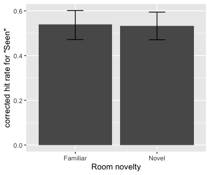

## 2.3 Any difference between *Early* and *Later* object groups?

### 2.3.1 Check the data

- **Is there any corrected hit rate < 0?**
- There are 0 negative values out of a total of 168 values.

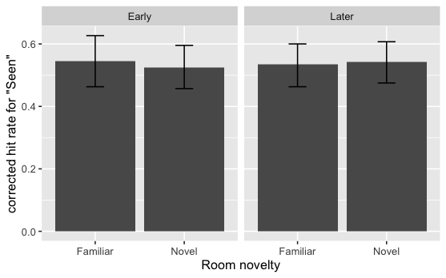

# 3 Curiosity Enhancement

## 3.1 Check the data

### 3.1.1 Is there any corrected hit rate < 0?

#### 3.1.1.1 For the data per room

| SubjectNo | Context | Group | CurRating | RoomOrder | Duration | SFHit | SHit | SrcHit | SFFalse | SFalse | SrcFalse | SFAcc | SAcc | SrcAcc |
| --- | --- | --- | --- | --- | --- | --- | --- | --- | --- | --- | --- | --- | --- | --- |
| P45 | Library | Familiar | 7 | First | 205.2989 | 0.3333333 | 0 | 0.1666667 | 0.4444444 | 0.2222222 | 0.1111111 | -0.1111111 | -0.2222222 | 0.05555556 |

#### 3.1.1.2 For the data per curiosity group

- There are 0 negative value for curiosity group (1 ~ 3 and 5 ~ 7) out of a total of 80 values.

#### 3.1.1.3 For the data per curiosity group (median)

- There are 0 negative value for curiosity group (median) out of a total of 83 values.

## 3.2 Mean accuracy of item memory as a function of curiosity rating

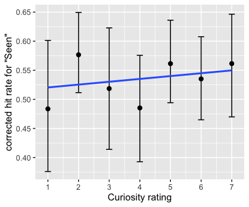

## 3.4 Check the curiosity groups

### 3.4.1 Separate the groups according to the rating

- *High*: curiosity rating > 4
- *Low*: curiosity rating < 4
- For curiosity rating = 4, discarded

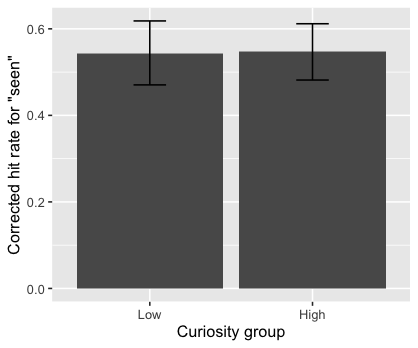

#### 3.4.1.1 Curiosity groups and temporal order of the objects

##### 3.4.1.1.1 Check the data

- **Is there any corrected hit rate < 0?**
- There are 0 negative values out of a total of 210 values.

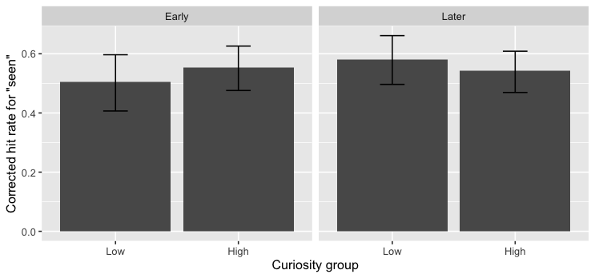

| CurGrp | ObjOrdGrp | Mean | SD | N |
| --- | --- | --- | --- | --- |
| NA | Early | 0.5748629 | 0.2673174 | 25 |
| High | Early | 0.5529547 | 0.2497881 | 42 |
| High | Later | 0.5415189 | 0.2315488 | 42 |
| Low | Later | 0.5813492 | 0.2649450 | 38 |
| NA | Later | 0.4948629 | 0.3133250 | 25 |
| Low | Early | 0.5045948 | 0.2913117 | 38 |

|  | Model | df | AIC | BIC | logLik | Test | L.Ratio | p-value |
| --- | --- | --- | --- | --- | --- | --- | --- | --- |
| baseline | 1 | 8 | -12.245690 | 12.35570 | 14.12284 |  |  |  |
| ord.model | 2 | 9 | -11.212137 | 16.46443 | 14.60607 | 1 vs 2 | 0.966447 | 0.3256 |
| cur.model | 3 | 10 | -9.311677 | 21.44006 | 14.65584 | 2 vs 3 | 0.099540 | 0.7524 |
| int.model | 4 | 11 | -10.728697 | 23.09821 | 16.36435 | 3 vs 4 | 3.417020 | 0.0645 |

```
Linear mixed-effects model fit by maximum likelihood
 Data: inside.hit.rate.item.order.curiosity[!is.na(CurGrp)]
```

|  | AIC | BIC | logLik |
| --- | --- | --- | --- |
|  | -10.7287 | 23.09822 | 16.36435 |

```
Random effects:
 Formula: ~1 + CurGrp + ObjOrdGrp | SubjectNo
 Structure: General positive-definite, Log-Cholesky parametrization
               StdDev    Corr
(Intercept)    0.2289268 (Intr) CrGrpH
CurGrpHigh     0.1400416 -0.453
ObjOrdGrpLater 0.1271239 -0.306 -0.159
Residual       0.1447984

Fixed effects: SAcc ~ ObjOrdGrp + CurGrp + ObjOrdGrp:CurGrp
```

|  | Value | Std.Error | DF | t-value | p-value |
| --- | --- | --- | --- | --- | --- |
| (Intercept) | 0.4993456 | 0.04377108 | 115 | 11.408118 | 0.0000 |
| ObjOrdGrpLater | 0.0754568 | 0.03944656 | 115 | 1.912885 | 0.0582 |
| CurGrpHigh | 0.0536091 | 0.04033654 | 115 | 1.329046 | 0.1865 |
| ObjOrdGrpLater:CurGrpHigh | -0.0868925 | 0.04674827 | 115 | -1.858733 | 0.0656 |

```
 Correlation:
                          (Intr) ObjOGL CrGrpH
ObjOrdGrpLater            -0.460
CurGrpHigh                -0.561  0.320
ObjOrdGrpLater:CurGrpHigh  0.282 -0.630 -0.578

Standardized Within-Group Residuals:
        Min          Q1         Med          Q3         Max
-2.37205709 -0.56499643  0.06027004  0.51591849  1.91421879

Number of Observations: 160
Number of Groups: 42
```

##### 3.4.1.1.2 *Post hoc*

```
     Simultaneous Tests for General Linear Hypotheses

Fit: lme.formula(fixed = SAcc ~ ObjOrdGrp + CurGrp + ObjOrdGrp:CurGrp,
    data = inside.hit.rate.item.order.curiosity[!is.na(CurGrp)],
    random = ~1 + CurGrp + ObjOrdGrp | SubjectNo, method = "ML",
    na.action = na.exclude, control = list(msMaxIter = 500, opt = "optim",
        msVerbose = FALSE))

Linear Hypotheses:
                         Estimate Std. Error z value Pr(>|z|)
Early: High vs. Low == 0  0.05361    0.03983   1.346    0.178
Late:  High vs. Low == 0 -0.03328    0.03991  -0.834    0.404
(Adjusted p values reported -- none method)
```

### 3.4.2 Separate the groups according to the median rating of each participant

- *High*: curiosity rating > median of the participant
- *Low*: curiosity rating < median of the participant

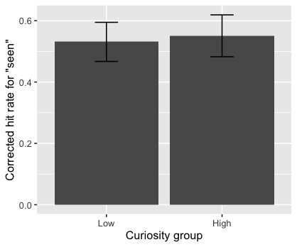

```
Linear mixed-effects model fit by maximum likelihood
 Data: inside.hit.rate.curiosity.group.median
```

|  | AIC | BIC | logLik |
| --- | --- | --- | --- |
|  | -24.85233 | -10.33929 | 18.42617 |

```
Random effects:
 Formula: ~1 + CurGrp | SubjectNo
 Structure: General positive-definite, Log-Cholesky parametrization
            StdDev     Corr
(Intercept) 0.19491370 (Intr)
CurGrpHigh  0.15807034 -0.328
Residual    0.07996794

Fixed effects: SAcc ~ CurGrp
```

|  | Value | Std.Error | DF | t-value | p-value |
| --- | --- | --- | --- | --- | --- |
| (Intercept) | 0.5319951 | 0.03290758 | 41 | 16.166338 | 0.0000 |
| CurGrpHigh | 0.0153466 | 0.03066708 | 40 | 0.500427 | 0.6195 |

```
 Correlation:
           (Intr)
CurGrpHigh -0.399

Standardized Within-Group Residuals:
        Min          Q1         Med          Q3         Max
-0.94708723 -0.32346870 -0.01666045  0.34603571  1.38544682

Number of Observations: 83
Number of Groups: 42
```

#### 3.4.2.1 Curiosity groups and temporal order of the objects

##### 3.4.2.1.1 Check the data

- **Is there any corrected hit rate < 0?**
- There are 0 negative values out of a total of 176 values.

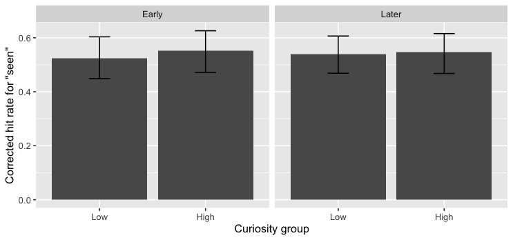

##### 3.4.2.1.2 *Post hoc*